# Лабораторная работа №1

## Создание ветки

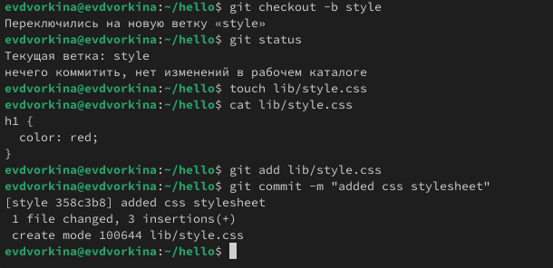

Создание ветки

## Создание ветки

Обновим файл hello.html, чтобы использовать стили style.css и index.html

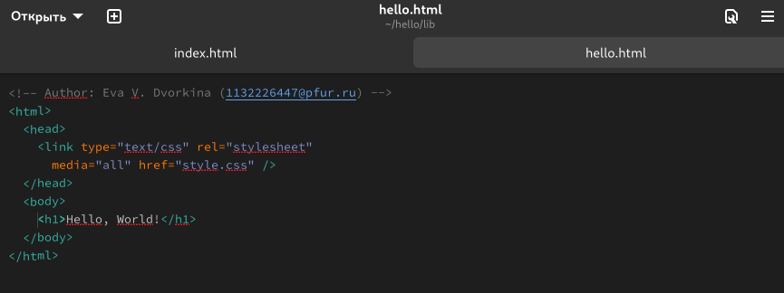

Редактирование файла hwllo.html

## Создание ветки

Обновиv файл index.html

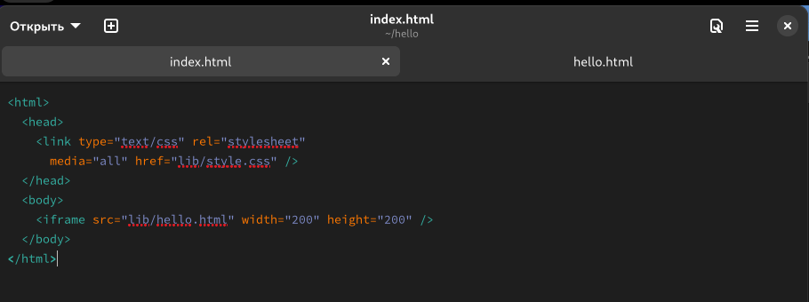

Редактирование файла index.html

## Создание ветки

Также обновим их в репозиторий

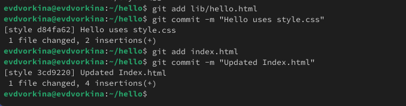

Создание ветки

## Навигация по веткам

Посмотрим все логи

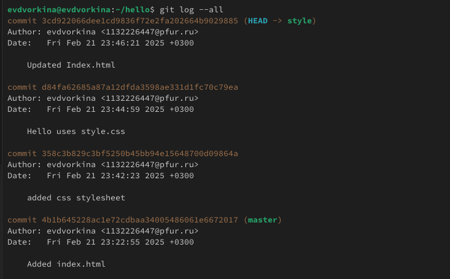

Просмотр логов новой ветки

Переключимся обратно на основную ветку и просмотрим содержимое файла `lib/hello.html`, заметим, что он не использует стили, не изменился, также просмотрим содержимое этого файла в новой ветке `style`, файл в ней уже использует стили

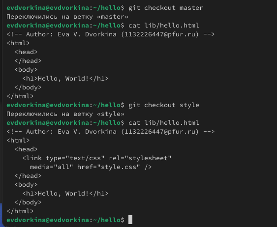

Сравнение изменений файла hello.html

## Изменения в ветке master

Вернемся в основную ветку и добавим файл README.md

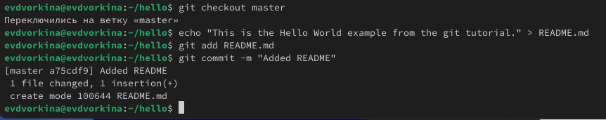

Изменения в ветке master

## Изменения в ветке master

Просмотрим ветки и их различия `git log --graph --all`

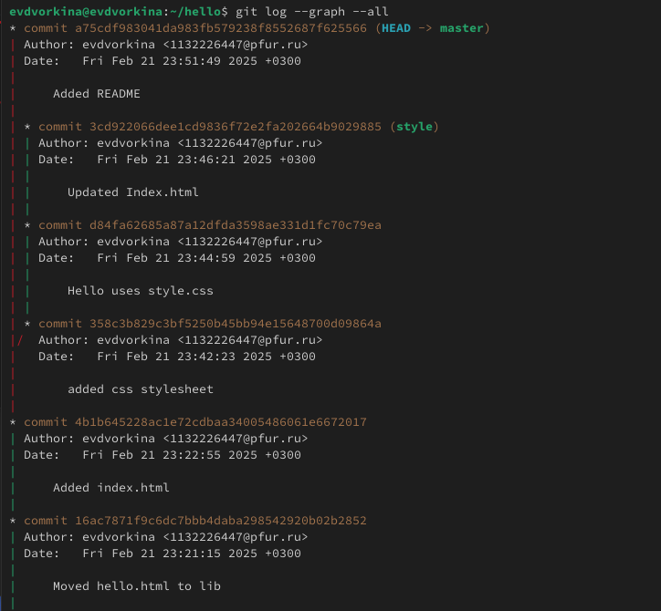

Изменения в ветке master

## Слияние

Слияние переносит изменения из двух веток в одну. Вернемся к ветке style и сольем master с style

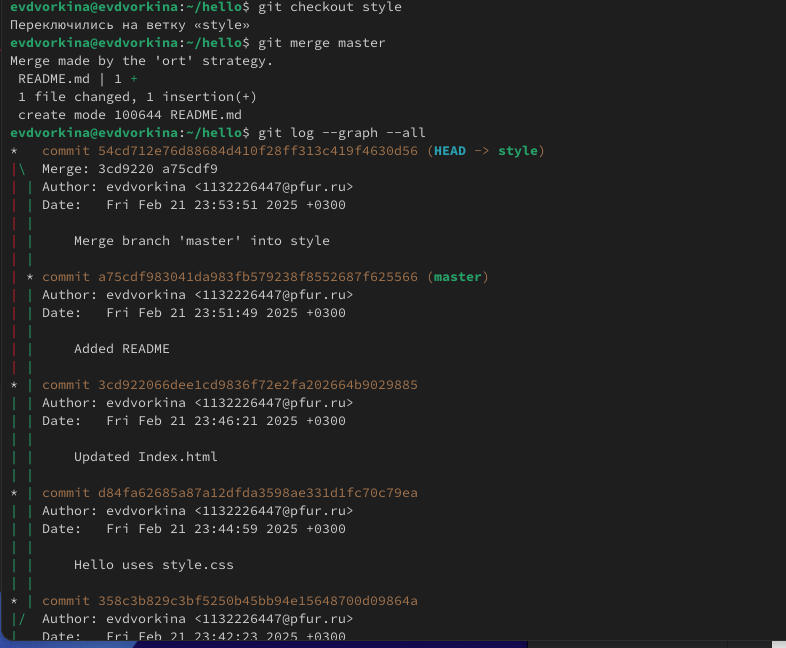

Слияние веток

## Создание конфликта

Вернемся в ветку master и создадим конфликт, внеся изменения в файл hello.html

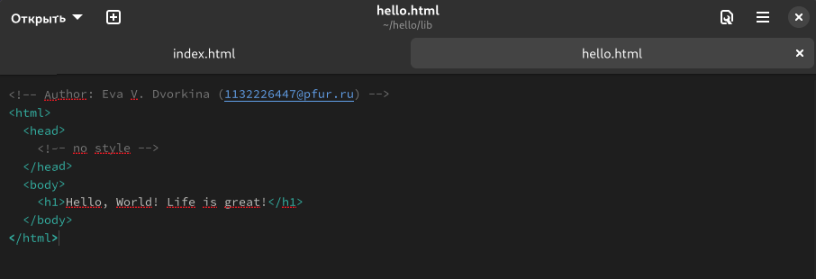

Создание конфликта

## Создание конфликта

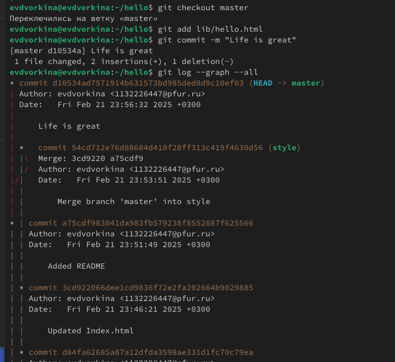

Создание конфликта

## Разрешение конфликтов

Вернемся к ветке style и попытаемся объединить ее с новой веткой master. В файле lib/hello.html можно увидеть записи с обеих версий этого файла. Первый раздел — версия текущей ветки (style). Второй раздел — версия ветки master. Внесем изменения в lib/hello.html, оставив только необходимую нам запись и добавим этот файл в репозиторий, чтобы вручную разрешить конфликт

## Разрешение конфликтов

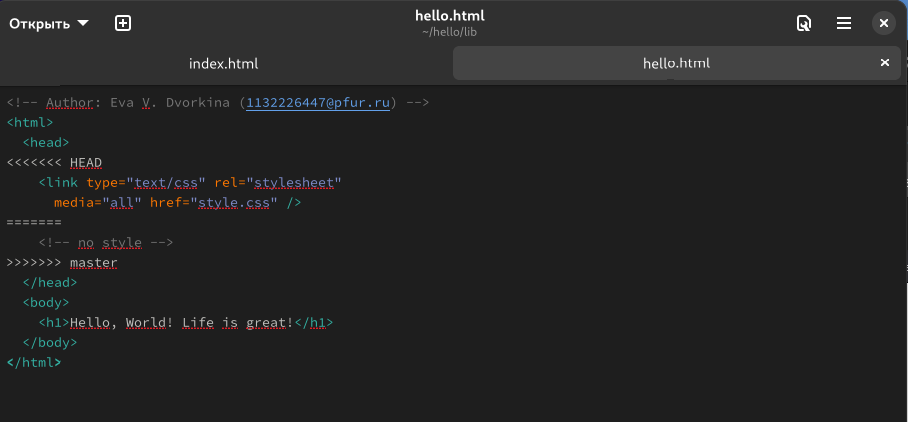

Конфликт

## Разрешение конфликтов

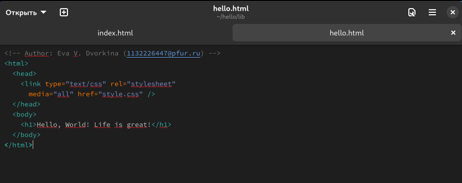

Разрешение конфликта

## Разрешение конфликтов

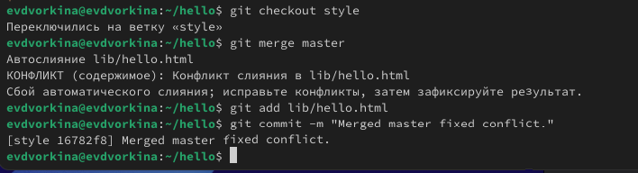

Коммит разрешения конфликта

## Сброс ветки style

Вернемся на ветку style к точке перед тем, как мы слили ее с веткой master. Мы хотим вернуться в ветке style в точку перед слиянием с master. Нам необходимо найти последний коммит перед слиянием .

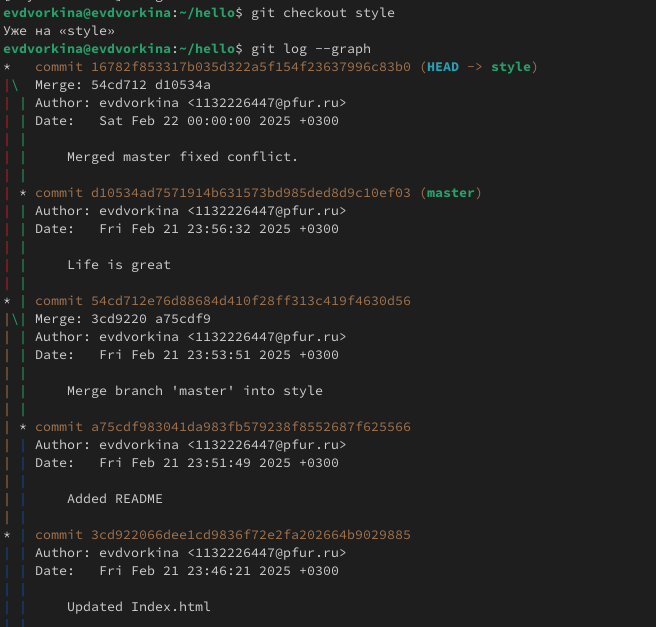

Поиск коммита перед слиянием

## Сброс ветки style

Мы видим, что коммит «Updated index.html» был последним на ветке style перед слиянием. Сбросим ветку style к этому коммиту.

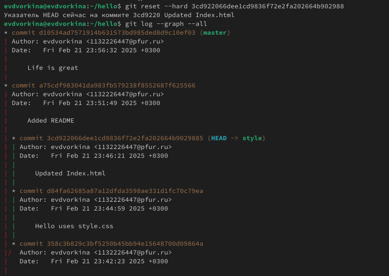

Сброс ветки style

## Сброс ветки master

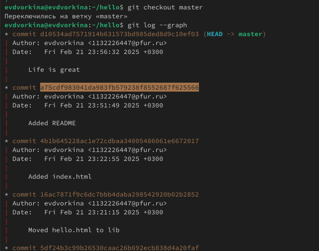

Поиск коммита перед конфликтом

## Сброс ветки master

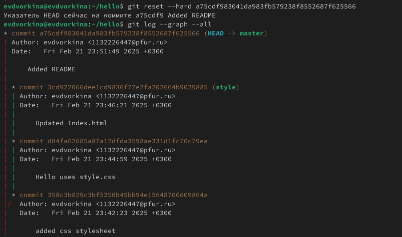

Сброс ветки master

## Перебазирование

Используем команду rebase вместо команды merge. Мы вернулись в точку до первого слияния и хотим перенести изменения из ветки master в нашу ветку style. На этот раз для переноса изменений из ветки master мы будем использовать команду git rebase вместо слияния

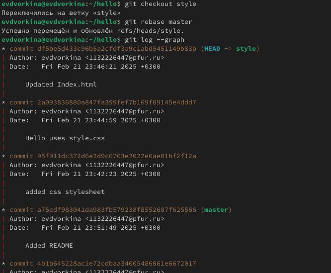

Перебазирование

## Слияние в ветку master

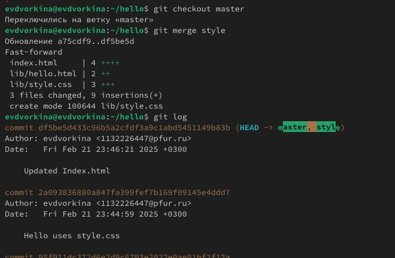

Слияние style в master

## Клонирование репозиториев

Перейдем в наш рабочий каталог и сделаем клон репозитория hello. Просмотрев его, увидим список всех файлов на верхнем уровне оригинального репозитория README.md, index.html и lib

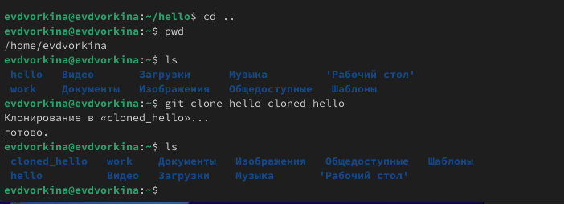

Клонирование репозиториев

## Клонирование репозиториев

Затем просмотрим историю репозитория и увидим список всех коммитов в новый репозиторий, и он совпадает с историей коммитов в оригинальном репозитории.

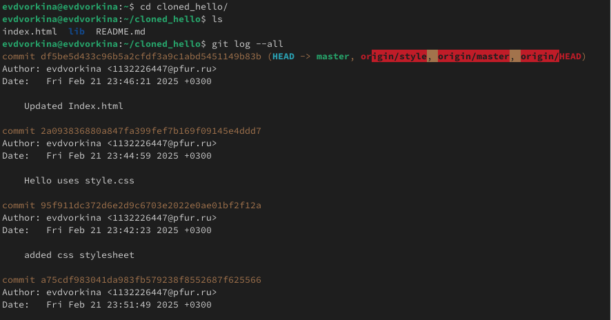

Клонирование репозиторв

## Что такое origin?

Клонированный репозиторий знает об имени по умолчанию удаленного репозитория. Посмотрим, подробную информацию об имени по умолчанию. .

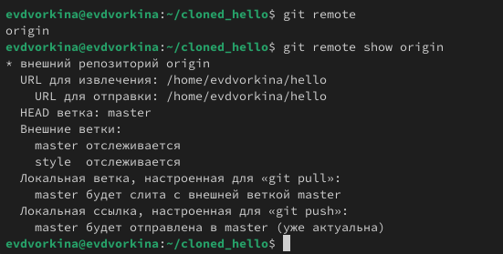

Просмотр имени по умолчанию удаленного репозитория

## Удаленные ветки

Посмотрим на ветки, доступные в нашем клонированном репозитории. Можно увидеть, что в списке только ветка master. Для того, чтобы увидеть все ветки используем опцию -a

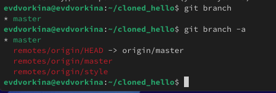

Просмотр веток

## Изменение оригинального репозитория

Перейдем в репозиторий hello. Внесем изменения в файл README.md. Затем добавим их в репозиторий

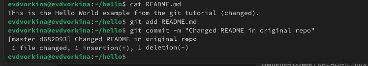

Изменение оригинального репозитория

## Изменение оригинального репозитория

Перейдём в клон репозитория и используем команду `git fetch`, которая будет извлекать новые коммиты из удаленного репозитория, но не будет сливать их с наработками в локальных ветках

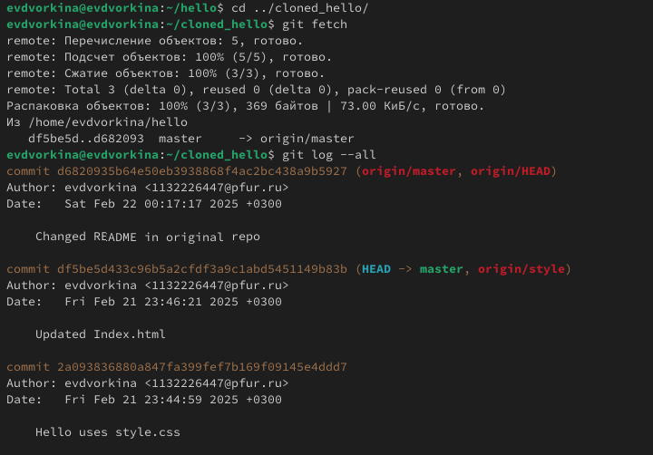

Извлечение изменений

## Слияние извлеченных изменений

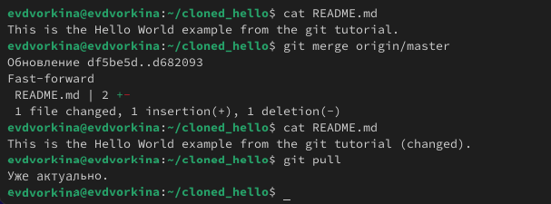

Слияние извлеченных изменений

## Добавление ветки наблюдения

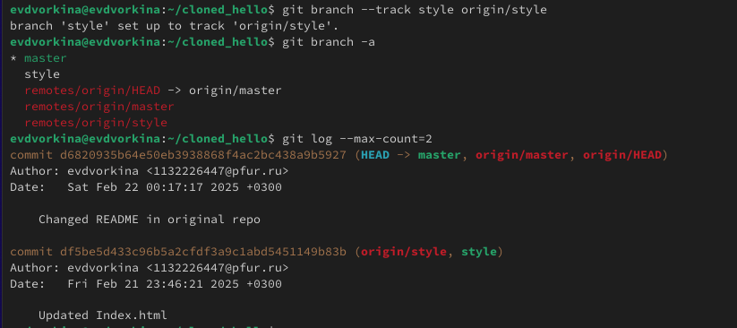

Добавление ветки наблюдения

## Создание чистого репозитория

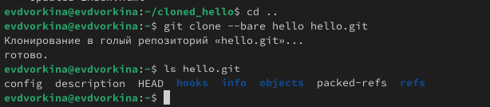

Создание чистого репозитория

## Отправка и извлечение изменений

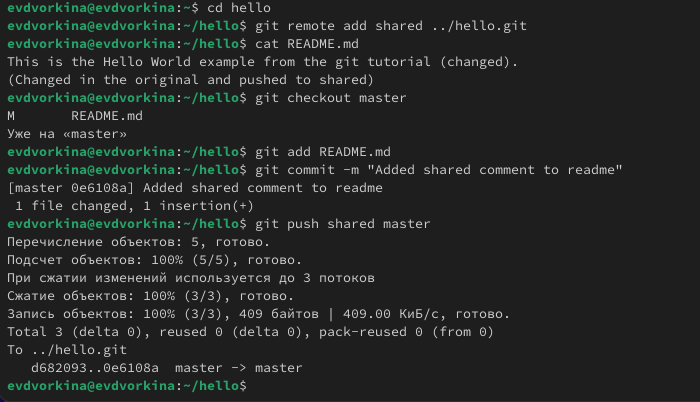

Отправка изменений

## Отправка и извлечение изменений

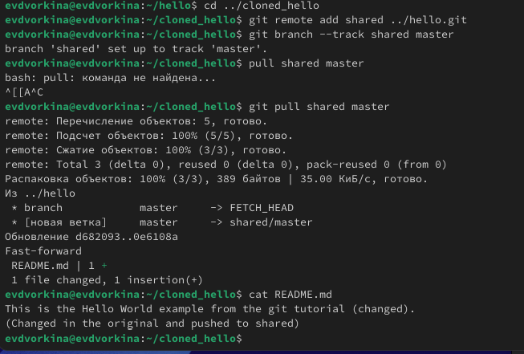

Извлечение изменений

## Выводы

В процессе выполнения данной лабораторной работы я приобрела практические навыки работы с Git.

# Cпасибо за внимание